# Practical_2

Soumarya Basak

16/04/2022

# Problem 1

```r
df<- read.csv("C:\\Users\\souma\\Dropbox\\Mstat_CU\\Sem 2\\Regression_analysis_1\\Data Sets\\con-exp_inc_dataset.csv")

colnames(df)<-c('x_var','y_var')
```

```r
lm_1<- lm(y_var~x_var,df)
summary(lm_1)
```

```
##
## Call:
## lm(formula = y_var ~ x_var, data = df)
##
## Residuals:
##      Min       1Q   Median       3Q      Max
## -2.44687 -0.94108  0.02916  1.19199  1.81151
##
## Coefficients:
##             Estimate Std. Error t value Pr(>|t|)
## (Intercept)  0.84705    0.70335   1.204    0.244
## x_var        0.89932    0.02531  35.534   <2e-16 ***
## ---
## Signif. codes:  0 '***' 0.001 '**' 0.01 '*' 0.05 '.' 0.1 ' ' 1
##
## Residual standard error: 1.314 on 18 degrees of freedom
## Multiple R-squared:  0.9859, Adjusted R-squared:  0.9852
## F-statistic:  1263 on 1 and 18 DF,  p-value: < 2.2e-16
```

# Scatter Plot

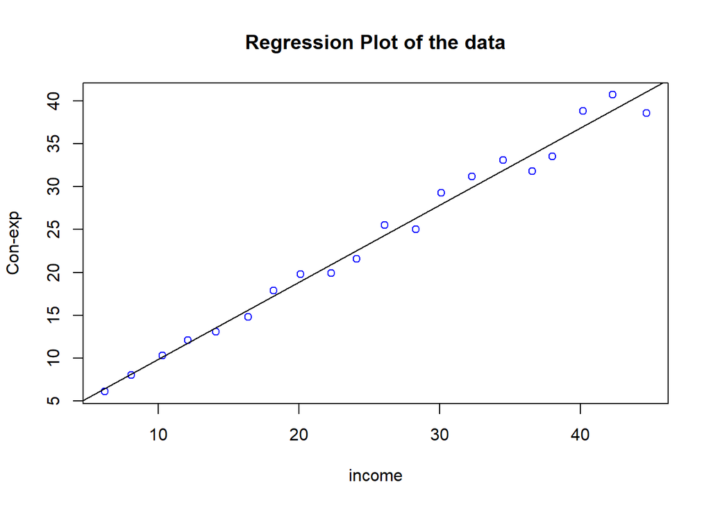

```r
plot(df$x_var,df$y_var,col="blue",
     main="Regression Plot of the data", xlab="income",ylab="Con-exp")
abline(lm_1)
```

The model is not fitted well as the intercept term is insignificant. There may be several reason of this — the data may consist influencial observations, the error variability may nit be coinstant etc. In the following section we will try t0 find them.

# Outlier

```r
influence.measures(lm_1)
```

```
## Influence measures of
##   lm(formula = y_var ~ x_var, data = df) :
##
##      dfb.1_ dfb.x_vr   dffit cov.r  cook.d    hat inf
## 1  -0.11552   0.0453 -0.1838 1.105 0.01727 0.0532
## 2  -0.03202   0.1450  0.2794 1.066 0.03889 0.0684
## 3   0.18229  -0.3787 -0.5417 0.925 0.13401 0.0978
## 4   0.10051  -0.0787  0.1050 1.253 0.00580 0.1142
## 5  -0.34877   0.5588  0.6760 1.018 0.21157 0.1579
## 6  -0.12527   0.1077 -0.1261 1.364 0.00839 0.1847   *
## 7   0.63252  -0.9594 -1.1173 0.804 0.50361 0.1904   *
## 8   0.07397   0.0154  0.2112 1.072 0.02250 0.0503
## 9   0.05756  -0.0467  0.0591 1.290 0.00185 0.1329
## 10 -0.27545   0.4715  0.5969 1.001 0.16594 0.1329
## 11 -0.04557   0.0382 -0.0462 1.332 0.00113 0.1591
## 12 -0.06951   0.1808  0.2902 1.096 0.04222 0.0817
## 13  0.17144  -0.3245 -0.4389 1.058 0.09344 0.1103
## 14 -0.10128   0.0754 -0.1088 1.224 0.00623 0.0961
## 15 -0.16052   0.1102 -0.1818 1.164 0.01711 0.0791
## 16 -0.08263   0.0161 -0.1635 1.114 0.01375 0.0505
## 17  0.00958   0.1050  0.2725 1.040 0.03674 0.0587
## 18 -0.04181  -0.0614 -0.2415 1.053 0.02911 0.0535
## 19  0.11892  -0.0745  0.1435 1.165 0.01073 0.0684
## 20  0.12826  -0.0693  0.1710 1.131 0.01507 0.0598
```

There are 2 influential obsn 6, 7 th obsn

SO we remove them from the model and refit the model below,

```r
df_updated<- df[-c(6,7),]

lm_1updated<- lm(y_var~x_var,df_updated)  # after removing influential observation
summary(lm_1updated)
```

```
##
## Call:
## lm(formula = y_var ~ x_var, data = df_updated)
##
## Residuals:
##     Min      1Q  Median      3Q     Max
## -2.3578 -0.9786  0.4246  0.9694  1.3282
##
## Coefficients:
##             Estimate Std. Error t value Pr(>|t|)
## (Intercept)  0.46505    0.75112   0.619    0.545
## x_var        0.92057    0.02752  33.452 3.08e-16 ***
## ---
## Signif. codes:  0 '***' 0.001 '**' 0.01 '*' 0.05 '.' 0.1 ' ' 1
##
## Residual standard error: 1.216 on 16 degrees of freedom
## Multiple R-squared:  0.9859, Adjusted R-squared:  0.985
## F-statistic:  1119 on 1 and 16 DF,  p-value: 3.082e-16
```

But still the model is iaapropiate as, the intersecp is still insignificant.

Lets check for the second reason.

# Residuals

Now we will find the residual form the updated fit.

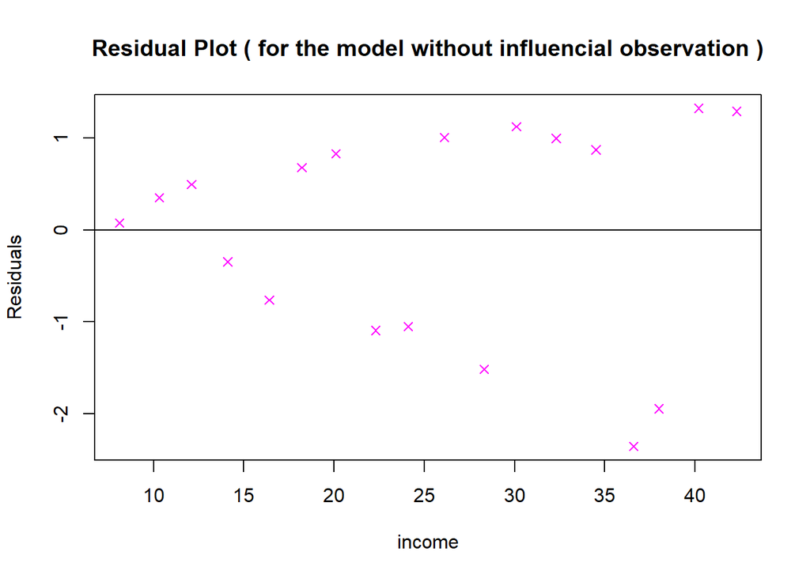

```r
res1<- resid(lm_1updated)  # residuals

plot(df_updated$x_var,res1,
     main="Residual Plot ( for the model without influencial observation )",
     xlab="income",ylab="Residuals", col="magenta",pch=4) # residual plot
abline(h=0)
```

So from the residual plot we notice that there is a heteroscedasticity, but to confirm that statisticaliy we should test for this.  
An famous test is **Goldfield Quant test**

### Goldfield Quant Test

```r
library(lmtest)
gqtest(lm_1updated,,fraction =6, order.by = ~df_updated$x_var,data = df_updated ) #alternative is more than
```

```
##
##  Goldfeld-Quandt test
##
## data:  lm_1updated
## GQ = 9.768, df1 = 4, df2 = 4, p-value = 0.02427
## alternative hypothesis: variance increases from segment 1 to 2
```

Since the p value is less than 0.05, we will reject the null hypothesis, so there is heteroscedasticity in the model.

So we need to workout with heteroscedasticity.

# Obtaining model for Residuals

We will fit an regression of $residual^2$ on x_var, where $residual_i^2$ can be looked upon as a estimate of $\sigma_i^2$

```r
df_res<-cbind(df_updated,res1^2) # add the (ei)^2 values
colnames(df_res)[3]<-"res"
```

```r
# the model for the sigma
res_lm1<-lm(res ~ x_var, data= df_res)
summary(res_lm1)
```

```
##
## Call:
## lm(formula = res ~ x_var, data = df_res)
##
## Residuals:
##     Min      1Q  Median      3Q     Max
## -1.3641 -0.4508 -0.1425  0.1342  3.2440
##
## Coefficients:
##             Estimate Std. Error t value Pr(>|t|)
## (Intercept) -0.90272    0.65934  -1.369  0.18987
## x_var        0.08792    0.02416   3.640  0.00221 **
## ---
## Signif. codes:  0 '***' 0.001 '**' 0.01 '*' 0.05 '.' 0.1 ' ' 1
##
## Residual standard error: 1.068 on 16 degrees of freedom
## Multiple R-squared:  0.4529, Adjusted R-squared:  0.4187
## F-statistic: 13.25 on 1 and 16 DF,  p-value: 0.002207
```

Now we see that intercept is insignificant.

So we drop the intercept from the model.

#### The Updated Model

```r
res_lm1_updated<- lm(res~ 0+ x_var, data= df_res)
summary(res_lm1_updated)
```

```
##
## Call:
## lm(formula = res ~ 0 + x_var, data = df_res)
##
## Residuals:
##     Min      1Q  Median      3Q     Max
## -1.2122 -0.5707 -0.4599 -0.2985  3.4601
##
## Coefficients:
##       Estimate Std. Error t value Pr(>|t|)
## x_var 0.057349   0.009455   6.065 1.26e-05 ***
## ---
## Signif. codes:  0 '***' 0.001 '**' 0.01 '*' 0.05 '.' 0.1 ' ' 1
##
## Residual standard error: 1.095 on 17 degrees of freedom
## Multiple R-squared:  0.684,  Adjusted R-squared:  0.6654
## F-statistic: 36.79 on 1 and 17 DF,  p-value: 1.261e-05
```

Now from the above model, we will find an estimate of $\sigma_i^2$, by fitting this model, and given by

```r
sigma_estimated<- predict(res_lm1_updated)
sigma_estimated
```

```
##         1         2         3         4         5         8         9        10
## 1.2788798 1.8523684 2.0989686 0.6939213 2.4258571 1.4968055 0.5906933 2.3054245
##        11        12        13        14        15        16        17        18
## 0.4645258 1.9785359 2.1792570 0.8086190 0.9405214 1.3821077 1.7262009 1.6229730
##        19        20
## 1.0437494 1.1527122
```

**The Plot of $x$ and $fitted(\sigma_i^2)$** (Unnecessary)

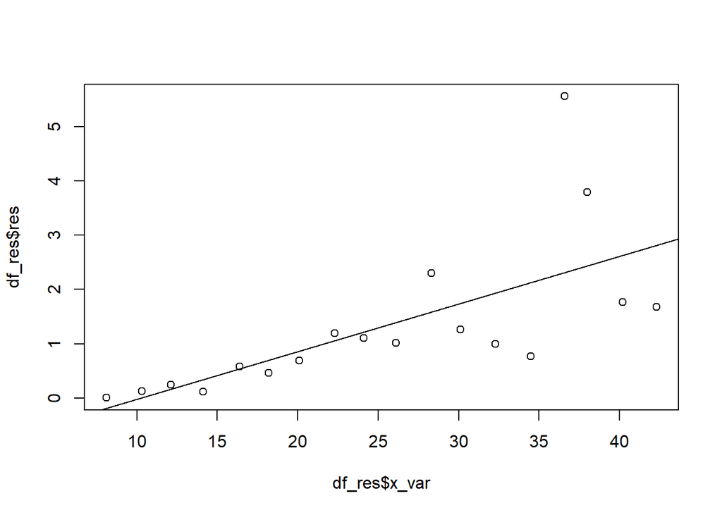

```r
plot(df_res$x_var,df_res$res)
abline(res_lm1)
```

## Estimated Omega hat

```r
omega<- diag(sigma_estimated)
```

## Model’s Design Matrix

```r
d_matrix <- model.matrix(lm_1updated)
d_matrix
```

```
##    (Intercept) x_var
## 1            1  22.3
## 2            1  32.3
## 3            1  36.6
## 4            1  12.1
## 5            1  42.3
## 8            1  26.1
## 9            1  10.3
## 10           1  40.2
## 11           1   8.1
## 12           1  34.5
## 13           1  38.0
## 14           1  14.1
## 15           1  16.4
## 16           1  24.1
## 17           1  30.1
## 18           1  28.3
## 19           1  18.2
## 20           1  20.1
## attr(,"assign")
## [1] 0 1
```

```r
a1<- solve( t(d_matrix) %*% solve(omega) %*% d_matrix )
a2<- t(d_matrix)  %*% solve(omega) %*% df_updated$y_var

beta_egls<- a1 %*% a2
beta_egls
```

```
##                  [,1]
## (Intercept) 0.6133042
## x_var       0.9146895
```

# The Model

$$y=0.6133042 + 0.9146895\times x$$

# The Scatter Plot

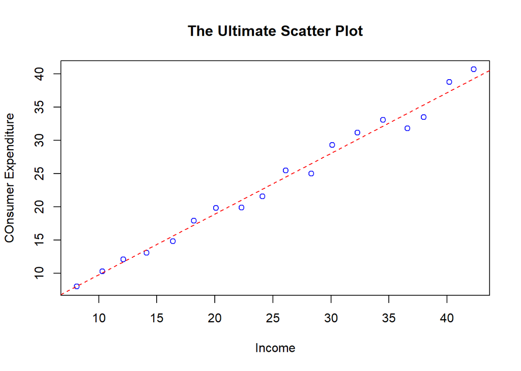

```r
plot(df_updated$x_var,df_updated$y_var,col='blue',
     xlab = "Income",ylab = "COnsumer Expenditure",
     main = "The Ultimate Scatter Plot")
abline(0.6133042, 0.9146895,col='red',lty=2)
```

# Problem 2

```r
library(tidyverse)
library(readr)
library(readxl)
```

```r
df<- read.csv("C:\\Users\\souma\\Dropbox\\Mstat_CU\\Sem 2\\Regression_analysis_1\\Data Sets\\dis_sp_dataset.csv")

colnames(df)<- c("y","x")   # y=dis , x= sp
head(df)
```

|  | y | x |
| --- | --- | --- |
| 1 | 4 | 4 |
| 2 | 2 | 5 |
| 3 | 4 | 5 |
| 4 | 8 | 5 |
| 5 | 8 | 5 |
| 6 | 7 | 7 |

## Lets fit the regression

```r
reg1<- lm(y~x,data=df)
summary(reg1)
```

```
##
## Call:
## lm(formula = y ~ x, data = df)
##
## Residuals:
##     Min      1Q  Median      3Q     Max
## -25.371  -7.401  -2.340   6.266  35.508
##
## Coefficients:
##             Estimate Std. Error t value Pr(>|t|)
## (Intercept) -20.4174     3.3446  -6.105 9.16e-08 ***
## x             3.1515     0.1559  20.213  < 2e-16 ***
## ---
## Signif. codes:  0 '***' 0.001 '**' 0.01 '*' 0.05 '.' 0.1 ' ' 1
##
## Residual standard error: 11.95 on 58 degrees of freedom
## Multiple R-squared:  0.8757, Adjusted R-squared:  0.8735
## F-statistic: 408.6 on 1 and 58 DF,  p-value: < 2.2e-16
```

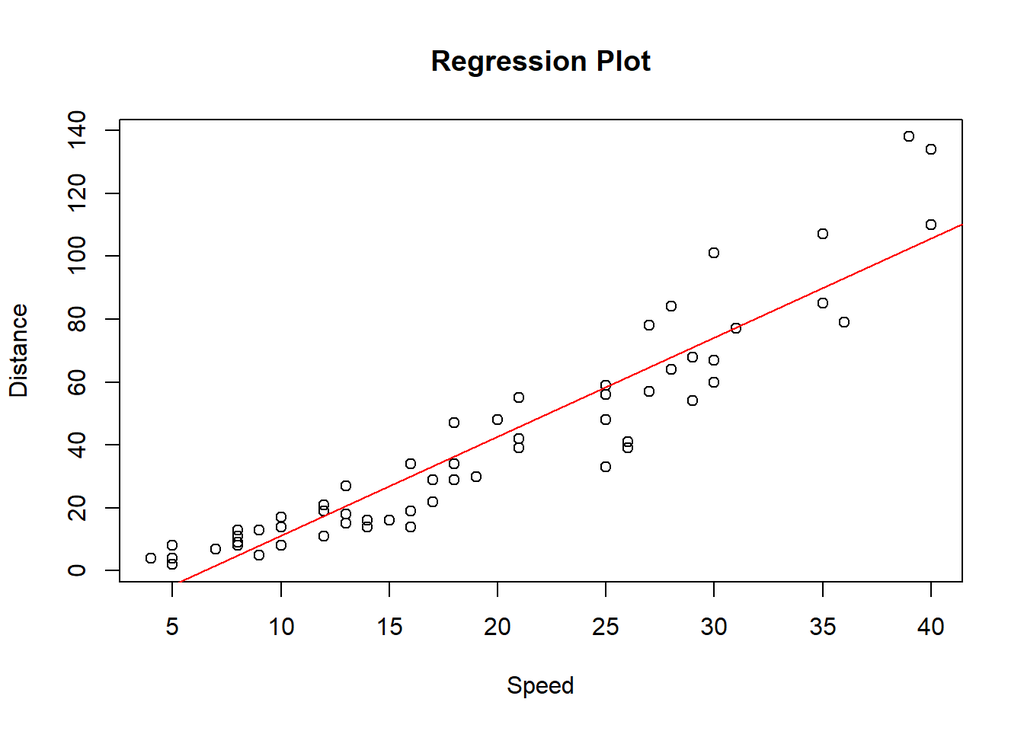

```r
# Scatter Plot
plot(df$x,df$y,
     main="Regression Plot",
     xlab = "Speed", ylab="Distance")

abline(reg1,col="red")
```

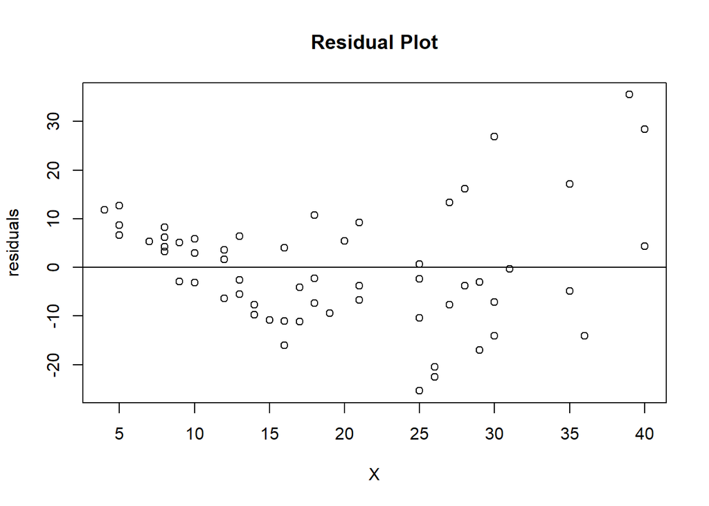

```r
# The residuals
res1<-resid(reg1)

# Residual Plot
plot(df$x,res1, main="Residual Plot",
     xlab = "X",ylab = "residuals")
abline(h=0)
```

From the residual plot we can suspect that there is a heterosecdasticity within the data, so should test for that. So we should go for the **Glejser test**

## Now lets check for Influencial Observation

```r
influence.measures(reg1)
```

```
## Influence measures of
##   lm(formula = y ~ x, data = df) :
##
##       dfb.1_     dfb.x    dffit cov.r   cook.d    hat inf
## 1   0.244429 -0.205256  0.24572 1.057 3.02e-02 0.0551
## 2   0.129506 -0.106811  0.13069 1.078 8.64e-03 0.0502
## 3   0.168729 -0.139161  0.17027 1.069 1.46e-02 0.0502
## 4   0.248027 -0.204562  0.25030 1.046 3.12e-02 0.0502
## 5   0.248027 -0.204562  0.25030 1.046 3.12e-02 0.0502
## 6   0.092346 -0.072912  0.09440 1.072 4.52e-03 0.0413
## 7   0.051765 -0.039792  0.05345 1.073 1.45e-03 0.0374
## 8   0.067948 -0.052231  0.07016 1.071 2.50e-03 0.0374
## 9   0.100395 -0.077173  0.10366 1.065 5.44e-03 0.0374
## 10  0.132995 -0.102233  0.13732 1.058 9.51e-03 0.0374
## 11  0.076362 -0.056896  0.07991 1.065 3.24e-03 0.0338
```

[output cut: 49 more lines]

So, we can see there are 4 influencial observation, viz 45,50,59,60 th observation.  
Lets remove these

### Regression fit after removing influencial

```r
df1<- df[-c(45,50,59,60),]
```

```r
reg2<- lm(y~x,data = df1)
summary(reg2)
```

```
##
## Call:
## lm(formula = y ~ x, data = df1)
##
## Residuals:
##      Min       1Q   Median       3Q      Max
## -20.6646  -5.7017   0.8999   5.0026  25.9591
##
## Coefficients:
##             Estimate Std. Error t value Pr(>|t|)
## (Intercept) -14.7762     2.7524  -5.369 1.71e-06 ***
## x             2.7376     0.1389  19.710  < 2e-16 ***
## ---
## Signif. codes:  0 '***' 0.001 '**' 0.01 '*' 0.05 '.' 0.1 ' ' 1
##
## Residual standard error: 9.194 on 54 degrees of freedom
## Multiple R-squared:  0.878,  Adjusted R-squared:  0.8757
## F-statistic: 388.5 on 1 and 54 DF,  p-value: < 2.2e-16
```

### Lets see the residual plot

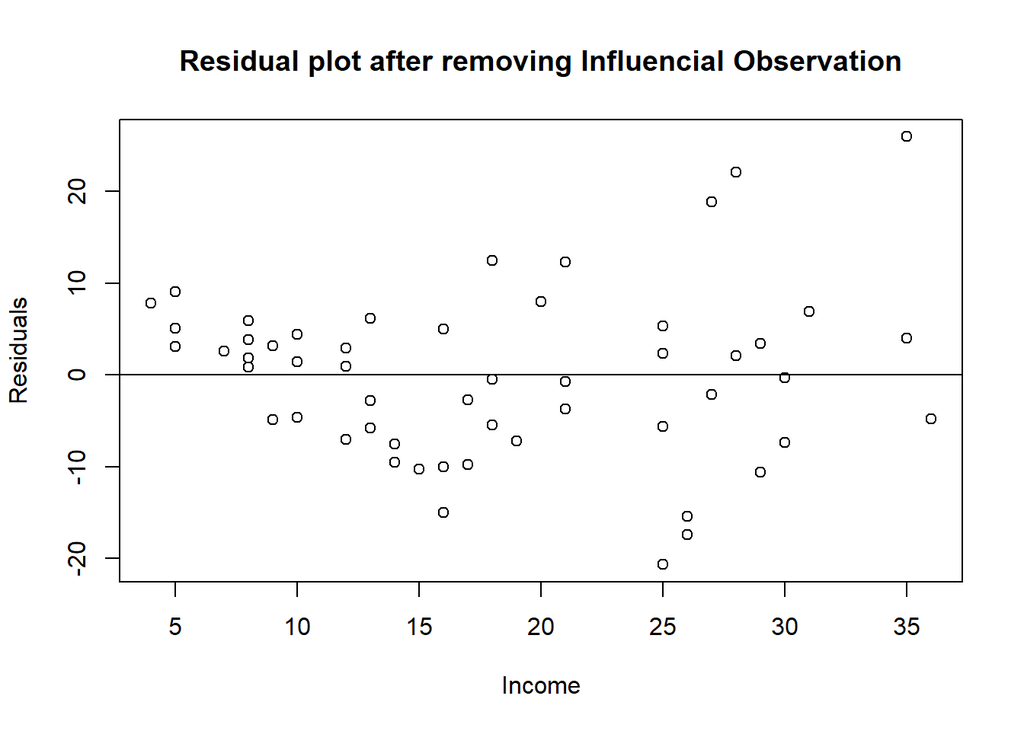

```r
# Model after removing influential observation
res2<- resid(reg2)
plot(df1$x,res2,main="Residual plot after removing Influencial Observation",
     xlab = "Income",ylab = "Residuals")
abline(h=0)
```

Still we can see that, there is a heteroscedasticity in the residuals. And the adjusted $R^2$ for the new model doesn’t change much  
So we will stick in the actual data set and previous model(`reg1` model), as removing data point causes information loss from our hand.

## Test For Heteroscedasticity

So we till test for heteroscedasticity by **Glejser Test**

```r
library(skedastic)
# Glejser Test
glejser(reg1)
```

| statistic | p.value | parameter | alternative |
| --- | --- | --- | --- |
| 12.49047 | 0.0004090322 | 1 | greater |

It results that the p value is less than 0.05, so, the presence of Heteroscedasticity statistically significant under 5% level of significant.

So now we will remove the heteroscedasticity from the model from the data set , assuming the error variance as a linear function of speed with an intercept term.

## Remedial Measure

```r
res1_sq<- res1^2 # ei Square

rem_lm<- lm(res1_sq~df$x)
summary(rem_lm)
```

```
##
## Call:
## lm(formula = res1_sq ~ df$x)
##
## Residuals:
##     Min      1Q  Median      3Q     Max
## -352.27  -97.17  -22.72   24.55  900.68
##
## Coefficients:
##             Estimate Std. Error t value Pr(>|t|)
## (Intercept)  -73.672     56.369  -1.307    0.196
## df$x          11.123      2.628   4.233 8.33e-05 ***
## ---
## Signif. codes:  0 '***' 0.001 '**' 0.01 '*' 0.05 '.' 0.1 ' ' 1
##
## Residual standard error: 201.4 on 58 degrees of freedom
## Multiple R-squared:  0.236,  Adjusted R-squared:  0.2228
## F-statistic: 17.92 on 1 and 58 DF,  p-value: 8.327e-05
```

But, the intercept term is insignificant, so we can drop this from the model. But here we are asked to work with an intercept term.

So the model is
$$e_i^2 = -73.672 + 11.123 \times x$$
#### So, the estiamted sigma_i sq hats are

```r
sigma_estimated<- predict(rem_lm)

omega<- diag(sigma_estimated)
```

## Lets find the design Matrix

```r
d_matrix<- model.matrix(reg1)
d_matrix
```

```
##    (Intercept)  x
## 1            1  4
## 2            1  5
## 3            1  5
## 4            1  5
## 5            1  5
## 6            1  7
## 7            1  8
## 8            1  8
## 9            1  8
## 10           1  8
## 11           1  9
## 12           1 10
## 13           1 10
## 14           1 10
```

[output cut: 48 more lines]

```r
a<- t(d_matrix) %*% solve(omega) %*% d_matrix
b<- t(d_matrix) %*% solve(omega) %*% df$y

beta_egls2 <- solve(a) %*% b
beta_egls2
```

```
##                   [,1]
## (Intercept) -24.118582
## x             3.345985
```

# The Final Model

So, after removing the heteroscedasticity, and find the final fitted model as,

$$y=-24.118582 + 3.345985\times x$$

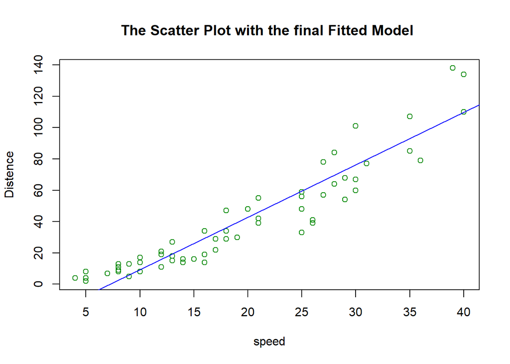

```r
plot(df$x,df$y,main = "The Scatter Plot with the final Fitted Model ",
     xlab = "speed",ylab = "Distence",col="green4")
abline(-24.118582,3.345985,col='blue')
```

# Problem 3

```r
library(tidyverse)
library(readr)
library(readxl)
```

```r
df<- read.csv("C:\\Users\\souma\\Dropbox\\Mstat_CU\\Sem 2\\Regression_analysis_1\\Data Sets\\stock_price_country.csv")
head(df)
```

|  | ï..Country | y | x |
| --- | --- | --- | --- |
| 1 | Australia | 5.0 | 4.3 |
| 2 | Austria | 11.1 | 4.6 |
| 3 | Belgium | 3.2 | 2.4 |
| 4 | Canada | 7.0 | 2.4 |
| 5 | Chile | 25.5 | 26.4 |
| 6 | Denmark | 3.8 | 4.2 |

# Plot the data and fit a suitable Regression

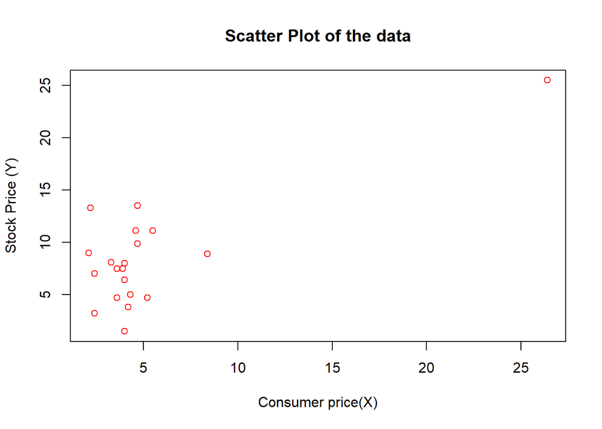

```r
plot(df$x,df$y, main="Scatter Plot of the data",
     xlab="Consumer price(X)",ylab = "Stock Price (Y)", col='red')
```

```r
# regission fit
reg3<- lm(y~x,data=df)
summary(reg3)
```

```
##
## Call:
## lm(formula = y ~ x, data = df)
##
## Residuals:
##     Min      1Q  Median      3Q     Max
## -6.0893 -2.6428  0.3132  1.9246  7.0829
##
## Coefficients:
##             Estimate Std. Error t value Pr(>|t|)
## (Intercept)   4.5400     1.0799   4.204 0.000533 ***
## x             0.7623     0.1493   5.108 7.36e-05 ***
## ---
## Signif. codes:  0 '***' 0.001 '**' 0.01 '*' 0.05 '.' 0.1 ' ' 1
##
## Residual standard error: 3.375 on 18 degrees of freedom
## Multiple R-squared:  0.5917, Adjusted R-squared:  0.569
## F-statistic: 26.09 on 1 and 18 DF,  p-value: 7.361e-05
```

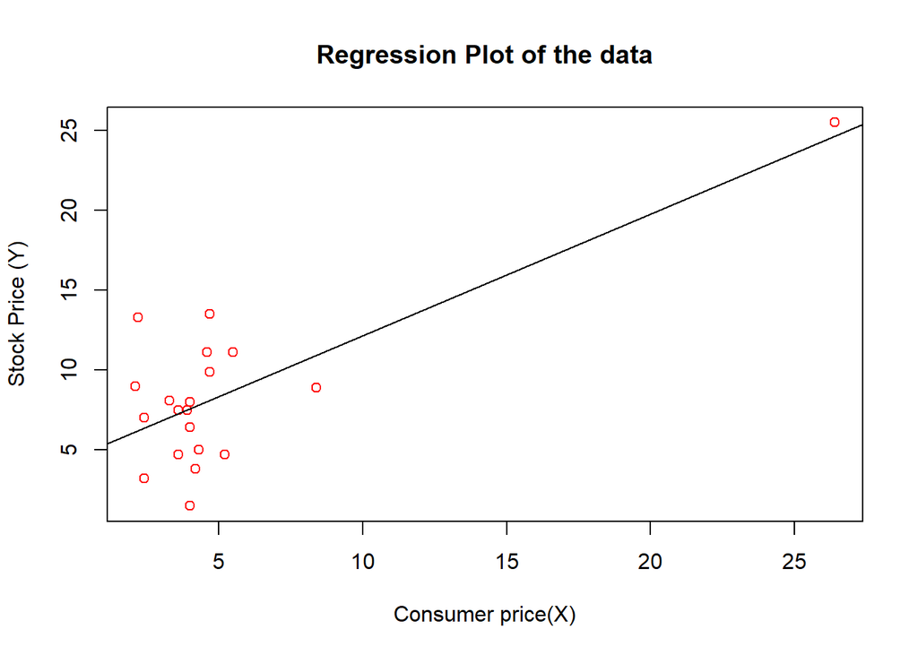

```r
plot(df$x,df$y, main="Regression Plot of the data",
     xlab="Consumer price(X)",ylab = "Stock Price (Y)", col='red')
abline(reg3)
```

## Lets check for influencial

```r
influence.measures(reg3)
```

```
## Influence measures of
##   lm(formula = y ~ x, data = df) :
##
##      dfb.1_     dfb.x     dffit  cov.r   cook.d    hat inf
## 1  -0.16066  0.033792 -0.198197  1.087 1.99e-02 0.0515
## 2   0.16556 -0.024128  0.213567  1.071 2.30e-02 0.0506
## 3  -0.24469  0.123032 -0.255743  1.077 3.28e-02 0.0651
## 4   0.04743 -0.023846  0.049568  1.194 1.30e-03 0.0651
## 5  -1.83474  3.343802  3.437398 14.652 5.95e+00 0.9308   *
## 6  -0.23349  0.053797 -0.284163  1.001 3.93e-02 0.0519
## 7   0.10631  0.010464  0.163152  1.113 1.37e-02 0.0502
## 8   0.09306 -0.011410  0.122009  1.143 7.75e-03 0.0504
## 9   0.63731 -0.334860  0.660395  0.654 1.70e-01 0.0673   *
## 10 -0.39799  0.106895 -0.472310  0.775 9.56e-02 0.0527
## 11 -0.07018  0.018848 -0.083281  1.166 3.65e-03 0.0527
## 12 -0.03474 -0.091250 -0.169706  1.154 1.49e-02 0.0703
## 13  0.06892 -0.026507  0.076246  1.175 3.06e-03 0.0569
## 14  0.30265 -0.037109  0.396805  0.856 7.10e-02 0.0504
## 15 -0.18631 -0.001325 -0.267936  1.011 3.52e-02 0.0500
## 16  0.01354 -0.004575  0.015387  1.186 1.25e-04 0.0549
## 17 -0.16511  0.055796 -0.187634  1.106 1.80e-02 0.0549
## 18  0.02416 -0.006488  0.028669  1.181 4.35e-04 0.0527
## 19 -0.00078  0.000224 -0.000915  1.184 4.43e-07 0.0532
## 20  0.22899 -0.122812  0.236377  1.103 2.83e-02 0.0685
```

The 5th and 9th obsn are influential

```r
df1<- df[-c(5,9),]
reg3_up<- lm(y~x,data=df1)
summary(reg3_up)
```

```
##
## Call:
## lm(formula = y ~ x, data = df1)
##
## Residuals:
##    Min     1Q Median     3Q    Max
## -5.672 -2.325  0.484  2.060  5.892
##
## Coefficients:
##             Estimate Std. Error t value Pr(>|t|)
## (Intercept)   4.6791     2.3140   2.022   0.0602 .
## x             0.6232     0.5284   1.179   0.2554
## ---
## Signif. codes:  0 '***' 0.001 '**' 0.01 '*' 0.05 '.' 0.1 ' ' 1
##
## Residual standard error: 3.063 on 16 degrees of freedom
## Multiple R-squared:  0.07999,    Adjusted R-squared:  0.02249
## F-statistic: 1.391 on 1 and 16 DF,  p-value: 0.2554
```

So its worst than the previous.

So, its better to stick with the original model

# Residual Plot

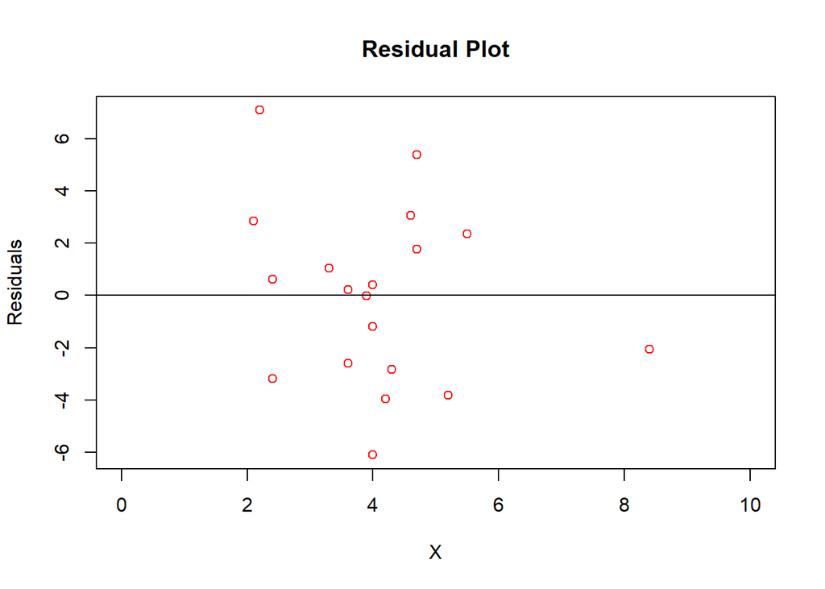

```r
res3<- resid(reg3)
# residual plot
plot(df$x,res3, xlim = c(0, 10),
     main="Residual Plot", xlab="X", ylab="Residuals", col='red')
abline(h=0)
```

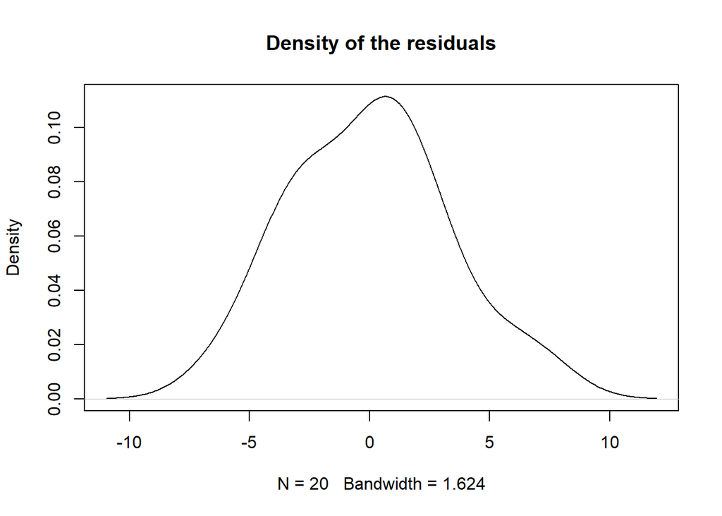

```r
plot(density(res3), main = "Density of the residuals")
```

# Goldfield Quant test

```r
library(lmtest)

gqtest(reg3,fraction = 6,order.by = ~x, data = df)
```

```
##
##  Goldfeld-Quandt test
##
## data:  reg3
## GQ = 1.0387, df1 = 5, df2 = 5, p-value = 0.4839
## alternative hypothesis: variance increases from segment 1 to 2
```

Since the p value is more than 0.05, So we fail to reject the null hypothesis, so the data is homoscedastic.

So OLS works good here.

# Parameter of the Model

```r
reg3$coefficients
```

```
## (Intercept)           x
##   4.5400120   0.7623165
```

# Final Model

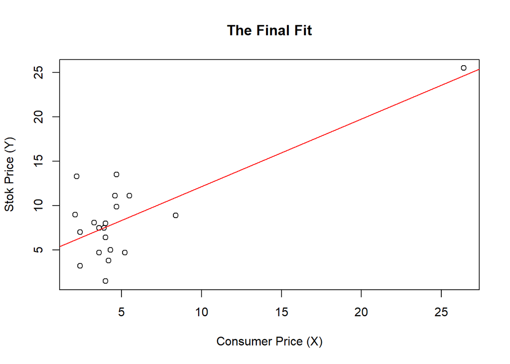

```r
plot(df$x,df$y, main = "The Final Fit",
     xlab = "Consumer Price (X)" , ylab="Stok Price (Y)")
abline(reg3,col='red')
```